# Лабораторная работа №7

Расширенные настройки межсетевого экрана (FirewallD)

Элсаиед Адел

3 января 2026

# Цели и ожидаемый результат

## Цель работы

Получить навыки настройки межсетевого экрана в Linux: - переадресация (port forwarding); - маскарадинг (masquerading / NAT).

# Выполнение работы

## Создание пользовательской службы FirewallD (ssh-custom)

- скопирован файл `/usr/lib/firewalld/services/ssh.xml`;
- создан пользовательский файл `/etc/firewalld/services/ssh-custom.xml`;
- изучена структура XML-описания службы.

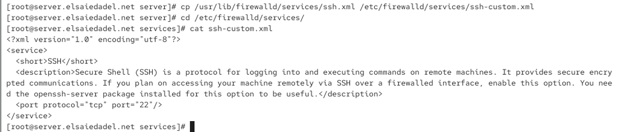

Просмотр содержимого ssh-custom.xml

## Редактирование ssh-custom: порт и описание

Изменения в `/etc/firewalld/services/ssh-custom.xml`: - порт SSH изменён со стандартного `22` на `2022`; - описание уточнено как пользовательская модификация.

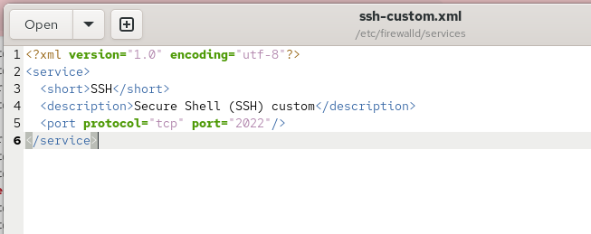

Редактирование порта и описания службы

## Активация службы ssh-custom

Служба добавлена в правила FirewallD:

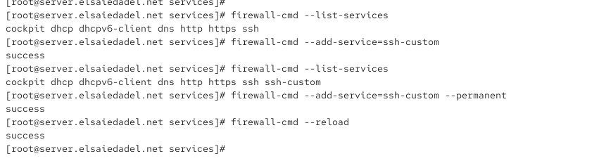

Добавление ssh-custom и перезагрузка FirewallD

## Перенаправление портов 2022 → 22 на сервере

Настройка позволяет: - принимать подключения на внешнем порту `2022`, - при этом обслуживать их локальной SSH-службой на `22`.

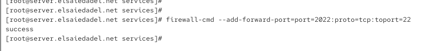

Настройка port forward 2022 -> 22

## Проверка SSH-подключения с клиента

На `client` выполнено подключение по SSH к `server` через порт `2022`.

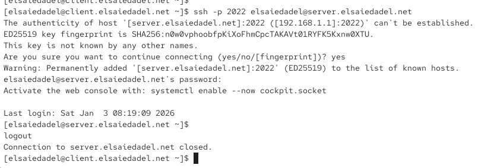

Проверка SSH-подключения через порт 2022

## Включение IPv4 forwarding + masquerading (NAT)

- создан `/etc/sysctl.d/90-forward.conf` с `net.ipv4.ip_forward = 1`;
- применены sysctl-настройки;
- включён masquerading (NAT) для зоны `public`;
- перезагружен FirewallD для применения конфигурации.

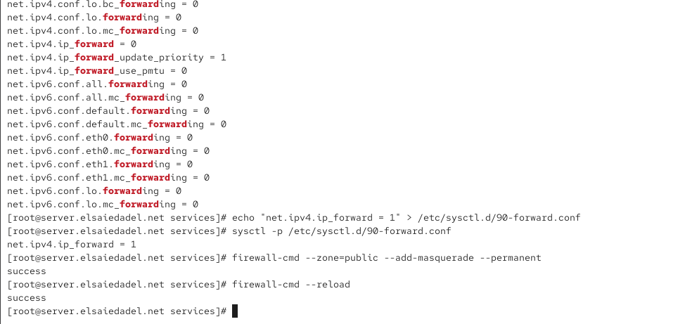

Включение ip_forward и masquerading

## Проверка выхода клиента в Интернет

На `client` проверен доступ во внешнюю сеть.

[figure not shown]

Проверка выхода в Интернет на клиенте

## Подготовка файлов в provision-структуре

Для воспроизводимости окружения подготовлены файлы в `/vagrant/provision/server/`: - `ssh-custom.xml` (служба FirewallD); - `90-forward.conf` (sysctl-настройка forwarding).

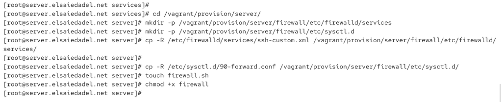

Подготовка каталогов и копирование конфигураций

## Скрипт firewall.sh для автоматической настройки

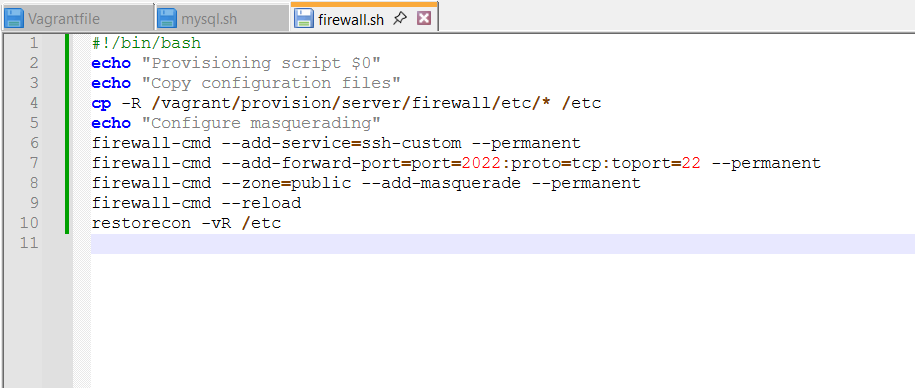

Содержимое скрипта firewall.sh

# Итоги

## Выводы по работе

В ходе лабораторной работы: - создана пользовательская служба FirewallD для SSH с портом `2022`; - настроено перенаправление `2022 → 22` и подтверждено успешным SSH-подключением; - включены IPv4 forwarding и masquerading для маршрутизации трафика клиента; - подготовлена автоматизация через provisioning для повторяемого развёртывания.